# Part IV

3. Set up hypotheses to test whether the mean yield for the control group is less than the mean yield from a plant given either of the treatments. Determine whether this test should proceed using a pooled estimate of the variance or whether Welch’s t-test would be more appropriate.

```r
head(PlantGrowth)
```

```
##   weight group
## 1   4.17  ctrl
## 2   5.58  ctrl
## 3   5.18  ctrl
## 4   6.11  ctrl
## 5   4.50  ctrl
## 6   4.61  ctrl
```

```r
levels(PlantGrowth[, 2])
```

```
## [1] "ctrl" "trt1" "trt2"
```

```r
data.1 <- PlantGrowth[PlantGrowth$group == "ctrl", ]
data.2 <- PlantGrowth[PlantGrowth$group != "ctrl", ]
#Hypotheses--> H0: ctrlmean-trtmean=0 // HA: ctrlmean-trtmean<0

#Rule of thumb
sd(PlantGrowth[PlantGrowth$group != "ctrl",1])/
      sd(PlantGrowth[PlantGrowth$group == "ctrl",1])
```

```
## [1] 1.315153
```

```r
# The rule of thumb states that there is enought to accept both variances are
# the same for that, we well use the pooled variance estimative test
```

4. Conduct the test and make a conclusion (assuming normality of the raw observations).

```r
t.test(PlantGrowth[PlantGrowth$group == "ctrl", 1],
       PlantGrowth[PlantGrowth$group != "ctrl", 1],
       alternative="less",
       var.equal = TRUE)
```

```
##
##  Two Sample t-test
##
## data:  PlantGrowth[PlantGrowth$group == "ctrl", 1] and PlantGrowth[PlantGrowth$group != "ctrl", 1]
## t = -0.22272, df = 28, p-value = 0.4127
## alternative hypothesis: true difference in means is less than 0
## 95 percent confidence interval:
##       -Inf 0.4082382
## sample estimates:
## mean of x mean of y
##    5.0320    5.0935
```

```r
# The p.value ~0.41 there is no evidence to reject H0 as it is bigger than the
#alpha 0.05. There is insufficient statistical evidence that the trtmean is
# greater than the ctrl mean
```

As discussed, there is a rule of thumb for deciding whether to use a pooled estimate of the variance in an unpaired t-test. e. Your task is to write a wrapper function that calls t.test after deciding whether it should be executed with var.equal=FALSE according to the rule of thumb. Use the following guidelines: – Your function should take four defined arguments: x and y with no defaults, to be treated in the same way as the same arguments in t.test; and var.equal and paired, with defaults that are the same as the defaults of t.test. – An ellipsis (Section 9.2.5) should be included to represent any additional arguments to be passed to t.test. – Upon execution, the function should determine whether paired=FALSE. * If paired is TRUE, then there is no need to proceed with the check of a pooled variance. * If paired is FALSE, then the function should determine the value for var.equal automatically by using the rule of thumb. – If the value of var.equal was set automatically, you can assume it will override any value of this argument initially supplied by the user. – Then, call t.test appropriately.

```r
my.t.test <- function(x,
                      y,
                      var.equal = FALSE,
                      paired = FALSE,
                      ...) {
      if (!paired) {
            var.equal <- max(c(sd(x), sd(y))) /
                  min(c(sd(x), sd(y))) < 2
      }
      return(t.test(
            x = x,
            y = y,
            var.equal = var.equal,
            paired = paired,
            ...
      ))
}
my.t.test2 <- function(x,
                      y,
                      var.equal = FALSE,
                      paired = FALSE,
                      ...) {
      if (paired) {
            var.equal <- max(c(sd(x), sd(y))) /
                  min(c(sd(x), sd(y))) < 2
      }
      return(t.test(
            x = x,
            y = y,
            var.equal = var.equal,
            paired = paired,
            ...
      ))
}
```

6. Try your new function on all three examples in the text of Section 18.2.2, ensuring you reach identical results.

```r
#i
snacks <- c(87.7,80.01,77.28,78.76,81.52,74.2,80.71,79.5,77.87,81.94,80.7,82.32,
            75.78,80.19,83.91,79.4,77.52,77.62,81.4,74.89,82.95,73.59,77.92,77.18,
            79.83,81.23,79.28,78.44,79.01,80.47,76.23,78.89,77.14,69.94,78.54,79.7,
            82.45,77.29,75.52,77.21,75.99,81.94,80.41,77.7)
snacks2 <- c(80.22,79.73,81.1,78.76,82.03,81.66,80.97,81.32,80.12,78.98,79.21,
             81.48,79.86,81.06,77.96,80.73,80.34,80.01,81.82,79.3,79.08,79.47,
             78.98,80.87,82.24,77.22,80.03,79.2,80.95,79.17,81)
my.t.test(snacks2,snacks,alternative="greater")
```

```
##
##  Welch Two Sample t-test
##
## data:  x and y
## t = 2.4455, df = 60.091, p-value = 0.008706
## alternative hypothesis: true difference in means is greater than 0
## 95 percent confidence interval:
##  0.3949381       Inf
## sample estimates:
## mean of x mean of y
##  80.15710  78.91068
```

```r
#ii
men <- c(102,87,101,96,107,101,91,85,108,67,85,82)
women <- c(73,81,111,109,143,95,92,120,93,89,119,79,90,126,62,92,77,106,105,111)

my.t.test(men,women,alternative="two.sided")
```

```
##
##  Two Sample t-test
##
## data:  x and y
## t = -0.93758, df = 30, p-value = 0.3559
## alternative hypothesis: true difference in means is not equal to 0
## 95 percent confidence interval:
##  -19.016393   7.049727
## sample estimates:
## mean of x mean of y
##  92.66667  98.65000
```

```r
#iii
rate.before <- c(52,66,89,87,89,72,66,65,49,62,70,52,75,63,65,61)
rate.after <- c(51,66,71,73,70,68,60,51,40,57,65,53,64,56,60,59)

my.t.test(rate.after,rate.before,alternative="less",paired=TRUE)
```

```
##
##  Paired t-test
##
## data:  x and y
## t = -4.8011, df = 15, p-value = 0.0001167
## alternative hypothesis: true difference in means is less than 0
## 95 percent confidence interval:
##       -Inf -4.721833
## sample estimates:
## mean of the differences
##                 -7.4375
```

Exercise 18.3

An advertisement for a skin cream claims nine out of ten women who use it would recommend it to a friend. A skeptical salesperson in a department store believes the true proportion of women users who’d recommend it, , is much smaller than 0:9. She follows up with 89 random customers who had purchased the skin cream and asks if they would recommend it to others, to which 71 answer yes.

1. Set up an appropriate pair of hypotheses for this test and determine whether it will be valid to carry out using the normal distribution.

```r
#Hypotheses: H0: p=0.9 // HA: p<0.9
p<-0.9
n<-89
x<-71
p.hat<-x/n
n*p.hat>5&n*(1-p.hat)>5
```

```
## [1] TRUE
```

```r
#as both are true, we can accept the to carry out with a normal distribution
```

2. Compute the test statistic and the p-value and state your conclusion for the test using a significance level of = 0:1.

```r
z.test<-(p.hat-p)/(sqrt(p*(1-p)/n))
pnorm(z.test)
```

```
## [1] 0.0006514802
```

```r
#the P-value is too small. with 99% of confidence, there is  enought statistical
#evidenve to reject H0 in favor of HA.
```

3. Using your estimated sample proportion, construct a two-sided 90 percent confidence interval for the true proportion of women who would recommend the skin cream.

```r
p.hat+c(-1,1)*qnorm(0.99)*sqrt(p*(1-p)/n)
```

```
## [1] 0.7237751 0.8717305
```

```r
#this result corroborates the answer in "B" as it excludes the claimmed mean of
#0.9
```

The political leaders of a particular country are curious as to the proportion of citizens in two of its states that support the decriminalization of marijuana. A small pilot survey taken by officials reveals that 97 out of 445 randomly sampled voting-age citizens residing in state 1 support the decriminalization and that 90 out of 419 votingage citizens residing in state 2 support the same notion.

4. Letting 1 denote the true proportion of citizens in support of decriminalization in state 1, and 2 the same measure in state 2, conduct and conclude a hypothesis test under a significance level of = 0:05 with reference to the following hypotheses:

```r
x1<-97
n1<-445
x2<-90
n2<-419

p.hat1<-x1/n1
p.hat2<-x2/n2

#d
alpha<-0.05
#Hypotheses:: H0: p2-p1 =0 // HA:p2-p1 != 0
prop.test(c(x2,x1),
          c(n2,n1),
          alternative = "two.sided",
          conf.level = 1-alpha,
          correct = FALSE)
```

```
##
##  2-sample test for equality of proportions without continuity
##  correction
##
## data:  c(x2, x1) out of c(n2, n1)
## X-squared = 0.012871, df = 1, p-value = 0.9097
## alternative hypothesis: two.sided
## 95 percent confidence interval:
##  -0.05811507  0.05175429
## sample estimates:
##    prop 1    prop 2
## 0.2147971 0.2179775
```

```r
#the P-value is a big one. There is not enought statistical evidence that
#the probability is different in each country. Pooled Variance
p<-(x1+x2)/(n1+n2)
#testing with the manual calculation
z<-(p.hat2-p.hat1)/(sqrt(p*(1-p)*(1/n1+1/n2)))
pval<-2*pnorm(z)
```

5. Compute and interpret a corresponding CI. Though there is standard, ready-to-use R functionality for the t-test, at the time of this writing, there is no similar function for the Z-test (in other words, the normal-based test of proportions described here) except in contributed packages.

```r
# statistic+critical Value*SE
se<-sqrt(p*(1-p)*(1/n1+1/n2))
(p.hat2-p.hat1)+c(-1,1)*qnorm(1-alpha/2)*se
```

```
## [1] -0.05812427  0.05176349
```

```r
#the CI includes the value 0 reassuring that both states might have the same
# proportion.
```

6. Your task is to write a relatively simple R function, Z.test, that can perform a one- or two-sample Z-test, using the following guidelines: – The function should take the following arguments: p1 and n1 (no default) to pose as the estimated proportion and sample size; p2 and n2 (both defaulting to NULL) that contain the second sample proportion and sample size in the event of a two-sample test; p0 (no default) as the null value; and alternative (default “two.sided”) and conf.level (default 0.95), to be used in the same way as in t.test. – When conducting a two-sample test, it should be p1 that is tested as being smaller or larger than p2 when alternative=“less” or alternative=“greater”, the same as in the use of x and y in t.test. – The function should perform a one-sample Z-test using p1, n1, and p0 if either p2 or n2 (or both) is NULL.

– The function should contain a check for the rule of thumb to ensure the validity of the normal distribution in both one- and two-sample settings. If this is violated, the function should still complete but should issue an appropriate warning message (see Section 12.1.1). – All that need be returned is a list containing the members Z (test statistic), P (appropriate p-value—this can be determined by alternative; for a two-sided test, determining whether Z is positive or not can help), and CI (two-sided CI with respect to conf.level).

```r
z.test <- function(p1,
                   n1,
                   p2 = NULL,
                   n2 = NULL,
                   p0,
                   alternative = "two.sided",
                   conf.level = 0.95) {

      if(is.null(p2)|is.null(n2)){
            cat("One sample Z-Test\n")
            if(p1*n1||n1*(1-p1)){
                  warning("normal distribution may not be valid")
            }
            z<-(p1-p0)/sqrt(p0*(1-p0)/n1)
            CI<-(p1)+c(-1,1)*qnorm(1-conf.level/2)*sqrt(p0*(1-p0)/n1)
      }else{
            cat("two-sample test")
            if(p1*n1<5||n1*(1-p1)<5||n2*p2<5||n2*(1-p2)<5){
                  warning("Normal distribution might not be accurate as rule
                          of thumb")
            }
            p.star(((n1*p1)+(n2*p2))/n1+n2)
            z<-(p1-p2-p0)/sqrt(p.star*(1-p.star)*(1/n1+1/n2))
            CI<-(p1-p1)+c(-1,1)*qnorm(1-conf.level/2)*
                  sqrt(p.star*(1-p.star)*(1/n1+1/n2))
            }
      #defining p-value
      p<-pnorm(z)
      if(alternative=="greater"){
            p<-1-p
      }
      if(alternative=="two.sided"){
            if(z>0){
                  p<-2*(1-p)
            }else{
                  p<-2*p
            }
      }
      return(list(Z=z,P=p,CI=CI))
}

sick <- c(0,0,1,1,0,0,0,0,0,1,0,0,0,0,0,0,0,0,1,0,0,0,1,1,1,0,0,0,1)
n.sick<-length(sick)
p.sick<-sum(sick)/n.sick
```

7. Replicate the two examples in the text of Sections 18.3.1 and 18.3.2 using Z.test; ensure you reach identical results.
8. Call Z.test(p1=0.11,n1=10,p0=0.1) to try your warning message in the one-sample setting.

Exercise 18.4

HairEyeColor is a ready-to-use data set in R that you haven’t yet come across. This 4 * 4 * 2 array provides frequencies of hair and eye colors of 592 statistics students, split by sex (Snee, 1974).

1. Perform and interpret, at a significance level of = 0:01, a chisquared test of independence for hair against eye color for all students, regardless of their sex.

```r
data(HairEyeColor)
total.hec<-HairEyeColor[,,1]+HairEyeColor[,,2]

chisq.test(total.hec)
```

```
##
##  Pearson's Chi-squared test
##
## data:  total.hec
## X-squared = 138.29, df = 9, p-value < 2.2e-16
```

```r
#H0:: Variables A and B are Independent // Ha: Variables are not independent
# We have a very small p.number. A strong statistical evidence to reject H0
```

In Exercise 8.1 on page 161, you accessed the Duncan data set of the contributed package car, which contains markers of job prestige collected in 1950. Install the package if you haven’t already and load the data frame. b. The first column of Duncan is the variable type, recording the type of job as a factor with three levels: prof (professional or managerial), bc (blue collar), and wc (white collar). Construct appropriate hypotheses and perform a chi-squared GOF test to determine whether the three job types are equally represented in the data set. i. Interpret the resulting p-value with respect to a significance level of = 0:05.

2. What conclusion would you reach if you used a significance level of = 0:01?

```r
library("car")
Duncan[,1]
```

```
##  [1] prof prof prof prof prof prof prof prof wc   prof prof prof prof prof prof
## [16] wc   prof prof prof prof wc   wc   wc   wc   bc   bc   bc   bc   bc   bc
## [31] bc   bc   bc   bc   bc   bc   bc   bc   bc   bc   bc   bc   bc   bc   bc
## Levels: bc prof wc
```

```r
c.prof<-length(Duncan[Duncan[,1]=="prof",1])
c.bc<-length(Duncan[Duncan[,1]=="bc",1])
c.wc<-length(Duncan[Duncan[,1]=="wc",1])


Duncan.tab<-table(Duncan[,1])

#Hypotheses: H0: p1=p2=p3=1 //Ha: h0 is incorrect

chisq.test(Duncan.tab)
```

```
##
##  Chi-squared test for given probabilities
##
## data:  Duncan.tab
## X-squared = 8.4, df = 2, p-value = 0.015
```

```r
#the P-value is lesser than the alpha=0.05, there is enough evidence to believe
# the Variables are dependent, following Ha

#B
#with alpha=0.01, the p.value becomes greater than it, we tend with H0, the
#variables are independent.
```

Exercise 18.5

1. Write a new version of typeI.tester called typeI.mean. The new function should be able to simulate the Type I error rate for tests of a single mean in any direction (in other words, oneor two-sided). The new function should take an additional argument, test, which takes a character string “less”, “greater”, or “two.sided” depending on the type of desired test. You can achieve this by modifying typeI.tester as follows: – Instead of calculating and storing the p-values directly in the for loop, simply store the test statistic.

– When the loop is complete, set up stacked if-else statements that cater to each of the three types of test, calculating the p-value as appropriate. – For the two-sided test, remember that the p-value is defined as twice the area “more extreme” than the null. Computationally, this means you must use the upper-tail area if the test statistic is positive and the lower-tail area otherwise. If this area is less than half of (since it is subsequently multiplied by 2 in a “real” hypothesis test), then a rejection of the null should be flagged. – If the value of test is not one of the three possibilities, the function should throw an appropriate error using stop. i. Experiment with your function using the first example setting in the text with 0 = 0,  = 1, n = 40, and = 0:05. Call typeI.mean three times, using each of the three possible options for test. You should find that all simulated results sit close to 0:05.

```r
typeI.mean<-function(mu0,sigma,n,alpha,ITERATIONS=10000,test="less"){

      t.stat<-rep(NA,ITERATIONS)
      pvals<-rep(NA,ITERATIONS)
      for(i in 1:ITERATIONS){
            temporary.sample<-rnorm(n=n,mean=mu0,sd=sigma)
            temporary.mean<-mean(temporary.sample)
            temporary.sd<-sd(temporary.sample)
            t.stat[i]<-(temporary.mean-mu0)/(temporary.sd/sqrt(n))
      }
      if(test=="less"){
        pvals<-pt(t.stat,df=n-1)
      }else
            if(test=="greater"){
            pvals<-1-pt(t.stat,df=n-1)
      }else
            if(test=="two.sided"){
            pvals[t.stat>=0]<-2*(1-pt(t.stat[t.stat>=0],df=n-1))
            pvals[t.stat<0]<-2*pt(t.stat[t.stat<0],df=n-1)

            }else {
            stop("Not a valid test input, please use \"less\",\"greater\", or
\"two.sided\"")
      }
      return(mean(pvals<alpha))
}

# i
typeI.mean(0,1,40,0.05,test="less")
```

```
## [1] 0.0467
```

```r
typeI.mean(0,1,40,0.05,test="greater")
```

```
## [1] 0.0479
```

```r
typeI.mean(0,1,40,0.05,test="two.sided")
```

```
## [1] 0.0533
```

2. Repeat (i) using the second example setting in the text with 0 = 4,  = 0:3, n = 60, and = 0:01. Again, you should find that all simulated results sit close to the value of .

```r
typeI.mean(-4,0.3,60,0.01,test="less")
```

```
## [1] 0.0085
```

```r
typeI.mean(-4,0.3,60,0.01,test="greater")
```

```
## [1] 0.0095
```

```r
typeI.mean(-4,0.3,60,0.01,test="two.sided")
```

```
## [1] 0.0103
```

2. Modify typeII.tester in the same way as you did typeI.tester; call the new function typeII.mean. Simulate the Type II error rates for the following hypothesis tests. As per the text, assume A, , , and n denote the true mean, standard deviation of raw observations, significance level, and sample size, respectively.

```r
typeII.mean<-function(mu0,muA,sigma,n,alpha,test="two.sided",ITERATIONS=10000){
      test.t<-rep(NA,ITERATIONS)
      for(i in 1:ITERATIONS){
            temporary.sample<-rnorm(n=n,mean=muA,sd=sigma)
            temporary.mean<-mean(temporary.sample)
            temporary.sd<-sd(temporary.sample)
            test.t[i]<-(temporary.mean-mu0)/(temporary.sd/sqrt(n))
      }
      pvals<-pt(test.t,df=n-1)
      if(test=="less"){
            return(mean(pvals>=alpha))
      }else if(test=="greater"){
            return(mean(1-pvals>=alpha))
      }else if(test=="two.sided"){
            result <- pvals
            result[test.t>0] <- 1-pvals[test.t>0]
            return(mean(result>=alpha/2))
      }else {
            stop("argument \"test\" is not valid. Please use \"less\",
\"greater\" or \"two.sided\"")
      }
}

#i
typeII.mean(-3.2,-3.3,0.1,25,0.05,"two.sided")
```

```
## [1] 0.0027
```

```r
#ii
typeII.mean(8994,5600,3888,9,0.01,"less")
```

```
## [1] 0.5589
```

```r
#iii
typeII.mean(0.44,0.4,2.4,68,0.05,"greater")
```

```
## [1] 0.967
```

Exercise 18.6

1. For this exercise you’ll need to have written typeII.mean from Exercise 18.5 (b). Using this function, modify power.tester so that a new function, power.mean, calls typeII.mean instead of calling typeII.tester.

```r
power.mean<-function(nvec,...){
      nlen<-length(nvec)
      result<-rep(NA,nlen)
      pbar<-txtProgressBar(min=0,max=nlen,style=3)
      for(i in 1:nlen){
            result[i]<-1-typeII.mean(n=nvec[i],...)
            setTxtProgressBar(pbar,i)
      }
      close(pbar)
      return(result)
}

#i
sample.sizes=5:100
power.mean(nvec=50,mu0=10,muA=10.5,sigma=0.9,alpha=0.01,test="two.sided")
```

```
## [1] 0.8843
```

```r
#ii
power.mean(nvec=44,mu0=80,muA=78.5,sigma=3.1,alpha=0.05,test="two.sided")
```

```
## [1] 0.8845
```

```r
power.mean(nvec=44,mu0=80,muA=78.5,sigma=3.1,alpha=0.01,test="two.sided")
```

```
## [1] 0.7054
```

2. Staying with the snacks hypothesis test, using the sample.sizes vector from the text, determine the minimum sample size required for a statistically powerful test using both = 0:05 and = 0:01. Produce a plot showing the two power curves.

```r
snacks <- c(87.7,80.01,77.28,78.76,81.52,74.2,80.71,79.5,77.87,81.94,80.7,82.32,
            75.78,80.19,83.91,79.4,77.52,77.62,81.4,74.89,82.95,73.59,77.92,
            77.18,79.83,81.23,79.28,78.44,79.01,80.47,76.23,78.89,77.14,69.94,
            78.54,79.7,82.45,77.29,75.52,77.21,75.99,81.94,80.41,77.7)

sample.sizes<- 5:100
```

# chapter 19: ANALYSIS OF VARIANCE

Exercise 19.1

These figures provide the depths (in centimeters) at which important archaeological finds were made at four sites in New Mexico (see Woosley and Mcintyre, 1996). Store these data in your R workspace, with one vector containing depth and the other vector containing the site of each observation.

```r
info<-data.frame("dep"=c(93,120,65,105,115,82,99,87,100,90,78,95,93,88,110,85,
                         45,80,28,75,70,65,55,50,40,100,75,65,40,73,65,50,30,
                         45,50,45,55,96,58,95,90,65,80,85,95,82),
                 "site"=c(rep("Site i",15),
                          rep("Site ii",10),
                          rep("Site iii",12),
                          rep("Site iv",9)))
```

1. Produce side-by-side boxplots of the depths split by group, and use additional points to mark the locations of the sample means.

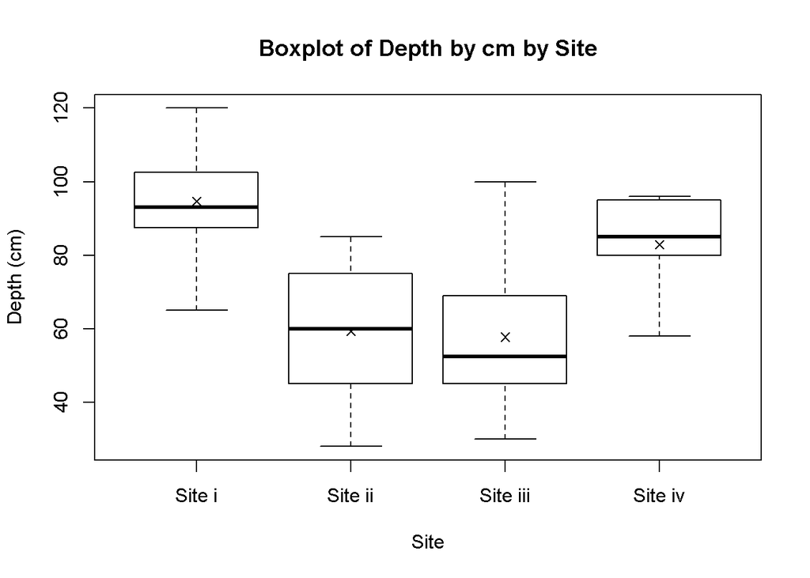

```r
infomean<-tapply(info$dep,info$site,mean)

boxplot(info$dep~info$site,
        xlab="Site",
        ylab="Depth (cm)",
        main="Boxplot of Depth by cm by Site")
points(1:4,infomean,pch=4)
```

2. Assuming independence, execute diagnostic checks for normality and equality of variances.

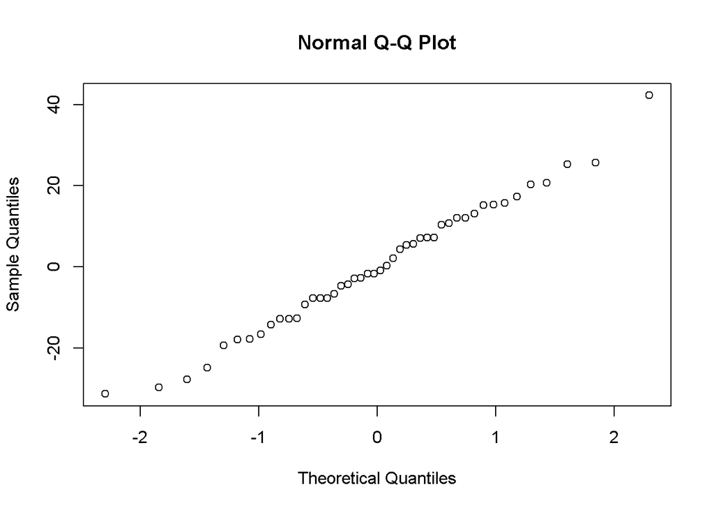

```r
infomeancen<-info$dep-infomean[as.numeric(info$site)]
qqnorm(infomeancen)
```

```r
#The chart provides enought information to accept the normality of the data

info.sds<-tapply(info$dep,info$site,sd)
max(info.sds)/min(info.sds)
```

```
## [1] 1.399928
```

```r
#to check the equality of variances we used the rule of thumb. as it is <2. We
#accept it
```

3. Perform and conclude a one-way ANOVA test for evidence of a difference between the means.

```r
infoaov<-aov(dep~site,info)
summary(infoaov)
```

```
##             Df Sum Sq Mean Sq F value   Pr(>F)
## site         3  12397    4132   15.14 7.99e-07 ***
## Residuals   42  11465     273
## ---
## Signif. codes:  0 '***' 0.001 '**' 0.01 '*' 0.05 '.' 0.1 ' ' 1
```

```r
#the p value is very small we have strong evidence to reject H0

dev.off()
```

In Section 14.4, you looked at the data set providing measurements on petal and sepal sizes for three species of iris flowers. This is available in R as iris.

4. Based on diagnostic checks for normality and equality of variances, decide which of the four outcome measurements (sepal length/width and petal length/width) would be suitable for ANOVA (using the species as the group variable).

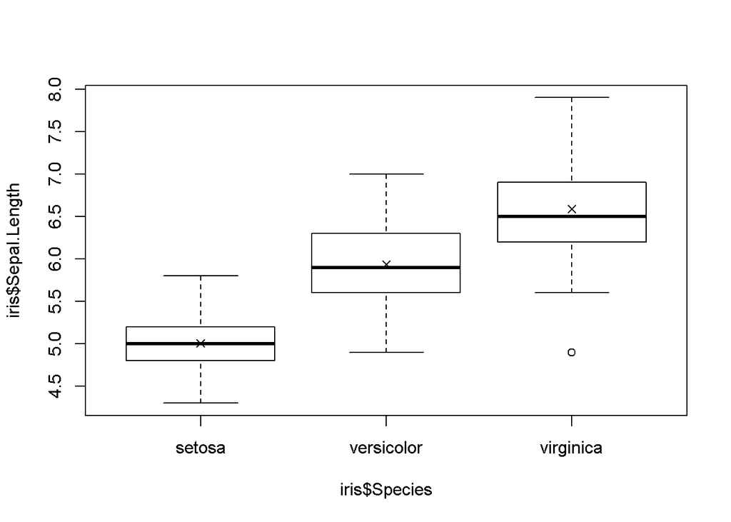

```r
sl.mean<-tapply(iris$Sepal.Length,iris$Species,mean) #mean
sl.meancen<-iris$Sepal.Length-sl.mean[as.numeric(iris$Species)] #mean centered
sl.sd<-tapply(iris$Sepal.Length,iris$Species,sd)

#checking variance
boxplot(iris$Sepal.Length~iris$Species)
      points(1:3,sl.mean,pch=4)
```

```r
max(sl.sd)/min(sl.sd)
```

```
## [1] 1.803967
```

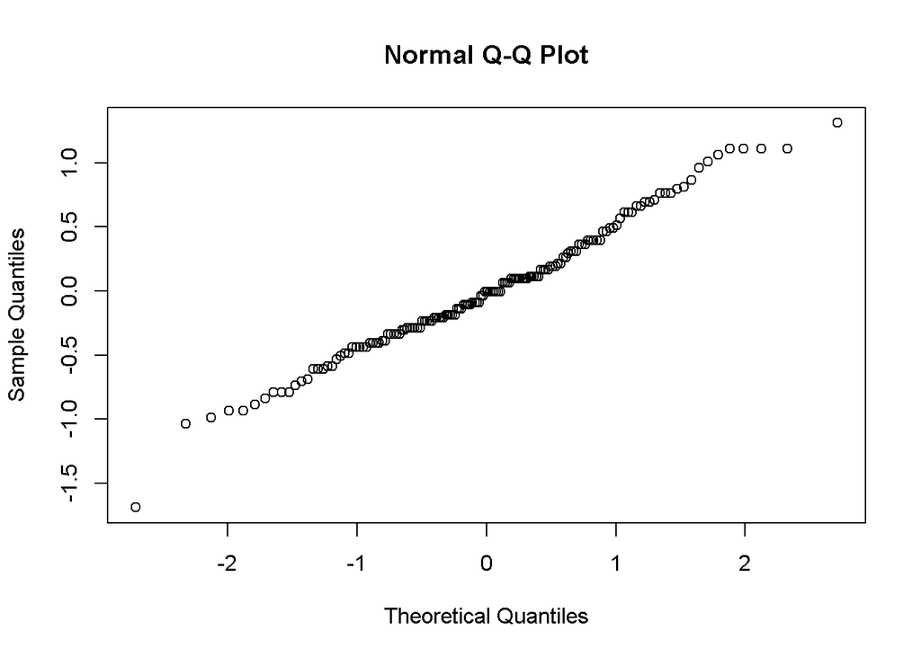

```r
#the variance in Boxplot looks acceptable and the rule of thumb <2 confirms this

#checking normality
qqnorm(sl.meancen)
```

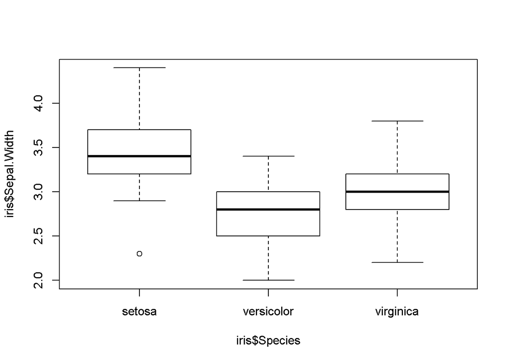

```r
#the data gathered looks normal as well. we can use this information for an ANOVA.
#Sepal.width ----
sw.mean<-tapply(iris$Sepal.Width,iris$Species,mean) #mean
sw.meancen<-iris$Sepal.Width-sw.mean[as.numeric(iris$Species)] #mean centered
sw.sd<-tapply(iris$Sepal.Width,iris$Species,sd)

#checking variance
boxplot(iris$Sepal.Width~iris$Species)
      points(1:3,sl.mean,pch=4)
```

```r
max(sw.sd)/min(sw.sd)
```

```
## [1] 1.207987
```

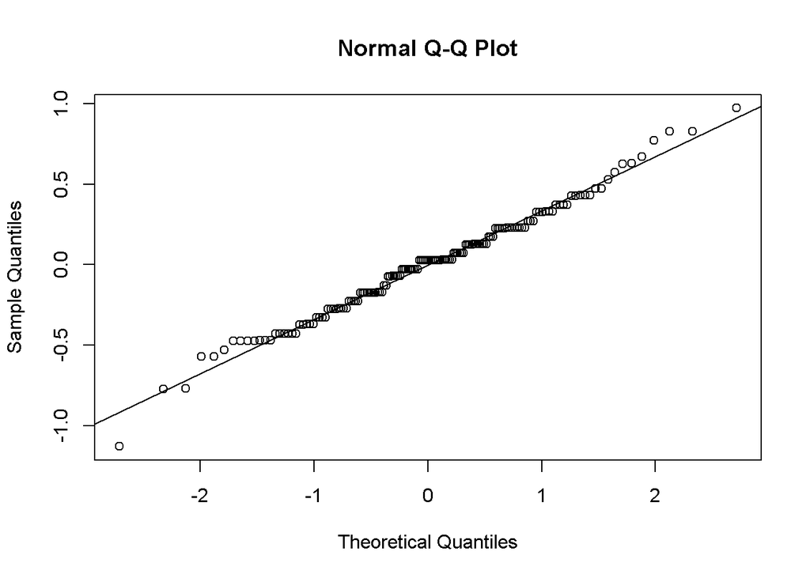

```r
#the variance in Boxplot looks acceptable and the rule of thumb <2 confirms this

#checking normality
qqnorm(sw.meancen)
qqline(sw.meancen)
```

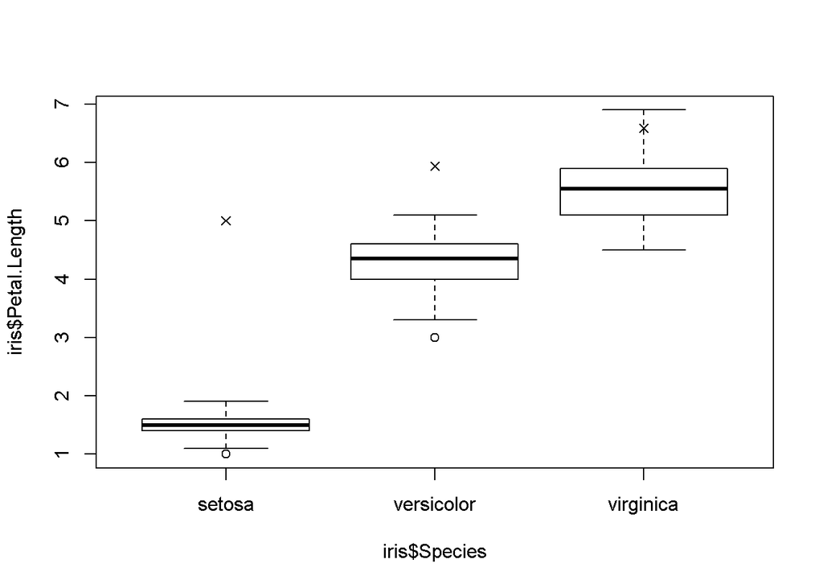

```r
#the data gathered looks normal as well. we can use this information for an
#ANOVA. This distributions looks mor normal then the previous
#Petal.Length ----
pl.mean<-tapply(iris$Petal.Length,iris$Species,mean) #mean
pl.meancen<-iris$Petal.Length-pl.mean[as.numeric(iris$Species)] #mean centered
pl.sd<-tapply(iris$Petal.Length,iris$Species,sd)

#checking variance
boxplot(iris$Petal.Length~iris$Species)
      points(1:3,sl.mean,pch=4)
```

```r
max(pl.sd)/min(pl.sd)
```

```
## [1] 3.177945
```

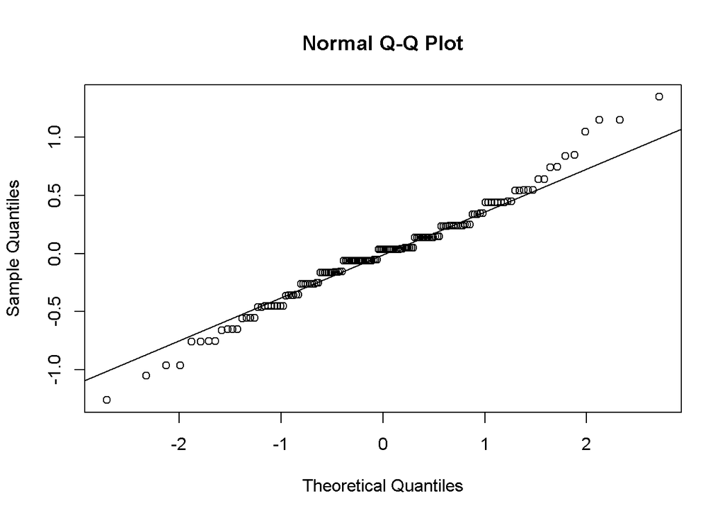

```r
#the variance in Boxplot does not look acceptable, and the rule of thumb is not
#<2. this is not a good data to proceed with ANOVA.

#checking normality
qqnorm(pl.meancen)
qqline(pl.meancen)
```

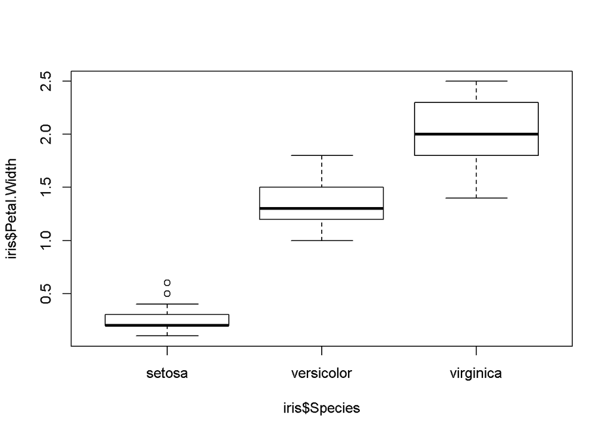

```r
#the data gathered looks normal as well. we can use this information for an
#ANOVA. This distributions looks mor normal then the previous
#Petal.width----
pw.mean<-tapply(iris$Petal.Width,iris$Species,mean) #mean
pw.meancen<-iris$Petal.Width-pw.mean[as.numeric(iris$Species)] #mean centered
pw.sd<-tapply(iris$Petal.Width,iris$Species,sd)

#checking variance
boxplot(iris$Petal.Width~iris$Species)
      points(1:3,sl.mean,pch=4)
```

```r
max(pw.sd)/min(pw.sd)
```

```
## [1] 2.606144
```

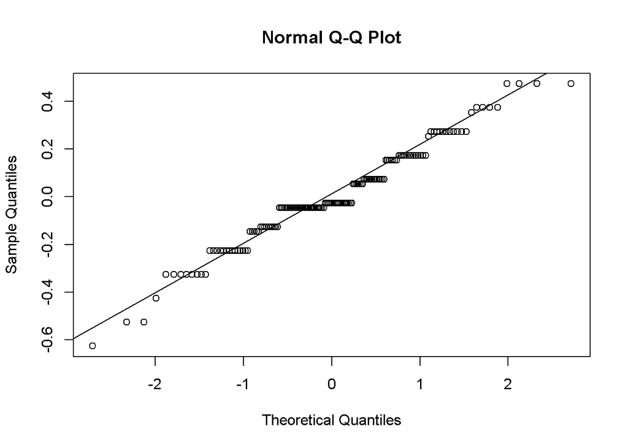

```r
#the variance in Boxplot does not look acceptable
#and the rule of thumb >2 confirms this

#checking normality
qqnorm(pw.meancen)
qqline(pw.meancen)
```

```r
#the data gathered looks normal as well. we can use this information for an
#ANOVA. This distributions looks mor normal then the previous
#the best way to use a ANOVA is with the Sepal analysis
```

5. Carry out one-way ANOVA for any suitable measurement variables.

```r
sl.aov<-aov(Sepal.Length~Species,iris)
summary(sl.aov)
```

```
##              Df Sum Sq Mean Sq F value Pr(>F)
## Species       2  63.21  31.606   119.3 <2e-16 ***
## Residuals   147  38.96   0.265
## ---
## Signif. codes:  0 '***' 0.001 '**' 0.01 '*' 0.05 '.' 0.1 ' ' 1
```

```r
#The pvalue is much less than the F value. We reject H0.

sw.aov<-aov(Sepal.Width~Species,iris)
summary(sl.aov)
```

```
##              Df Sum Sq Mean Sq F value Pr(>F)
## Species       2  63.21  31.606   119.3 <2e-16 ***
## Residuals   147  38.96   0.265
## ---
## Signif. codes:  0 '***' 0.001 '**' 0.01 '*' 0.05 '.' 0.1 ' ' 1
```

```r
#The pvalue is much less than the F value. We reject H0.
```

Exercise 19.2 Bring up the quakes data frame again, which describes the locations, magnitudes, depths, and number of observation stations that detected 1,000 seismic events off the coast of Fiji. a. Use cut (see Section 4.3.3) to create a new factor vector defining the depths of each event according to the following three categories: (0;200], (200;400], and (400;680].

```r
depth.fac <- cut(quakes$depth,breaks=c(0,200,400,680))
table(depth.fac)
```

```
## depth.fac
##   (0,200] (200,400] (400,680]
##       418       185       397
```

2. Decide whether a one-way ANOVA or a Kruskal-Wallis test is more appropriate to use to compare the distributions of the number of detecting stations, split according to the three categories in (a).

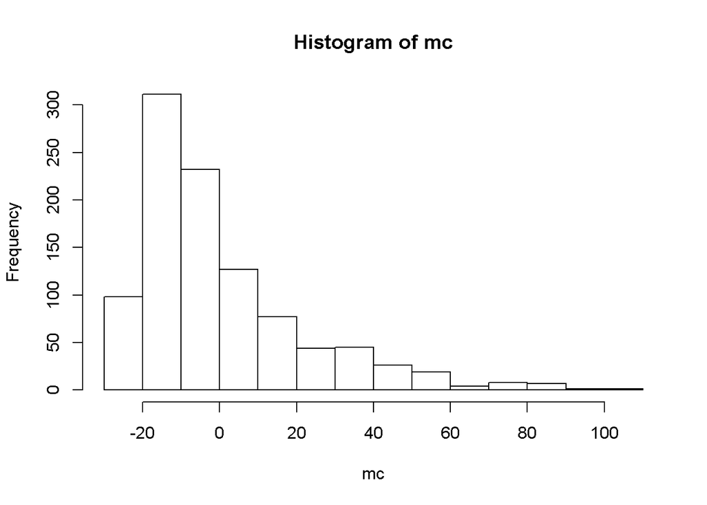

```r
m <- tapply(quakes$stations,depth.fac,mean)
mc <- quakes$stations-m[as.numeric(depth.fac)]
hist(mc)
```

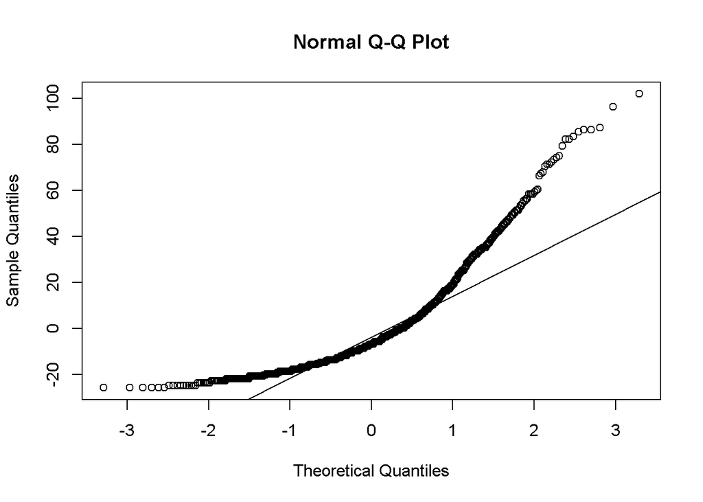

```r
qqnorm(mc)
qqline(mc) # Data appear non-normal... Kruskal-Wallis preferred over
```

```r
# parametric one-way ANOVA
```

3. Perform your choice of test in (b) (assume a = 0:01 level of significance) and conclude.

```r
kruskal.test(quakes$stations~depth.fac) # P-value > 0.01 (just barely);
```

```
##
##  Kruskal-Wallis rank sum test
##
## data:  quakes$stations by depth.fac
## Kruskal-Wallis chi-squared = 9.0943, df = 2, p-value = 0.0106
```

```r
#retain null. Minimal evidence, at best, of a difference in median
#number of detecting stations according to depth.fac categories.
```

Load the MASS package with a call to library(“MASS”) if you haven’t already done so in the current R session. This package includes the ready-to-use Cars93 data frame, which contains detailed data on 93 cars for sale in the United States in 1993 (Lock, 1993; Venables and Ripley, 2002). d. Use aggregate to compute the mean length of the 93 cars, split by two categorical variables: AirBags (type of airbags available—levels are Driver & Passenger, Driver only, and None), and Man.trans.avail (whether the car comes in a manual transmission—levels are Yes and No).

```r
library("MASS")
cars.means <- aggregate(Cars93$Length,
                        by=list(Cars93$AirBags,
                                Cars93$Man.trans.avail),
                        FUN=mean)
cars.means
```

```
##              Group.1 Group.2        x
## 1 Driver & Passenger      No 197.5000
## 2        Driver only      No 197.8750
## 3               None      No 191.3750
## 4 Driver & Passenger     Yes 189.0000
## 5        Driver only     Yes 178.0370
## 6               None     Yes 170.8462
```

5. Produce an interaction plot using the results in (d). Does there appear to be an interactive effect of AirBags with Man.trans.avail on the mean length of these cars (if you consider only these variables)?

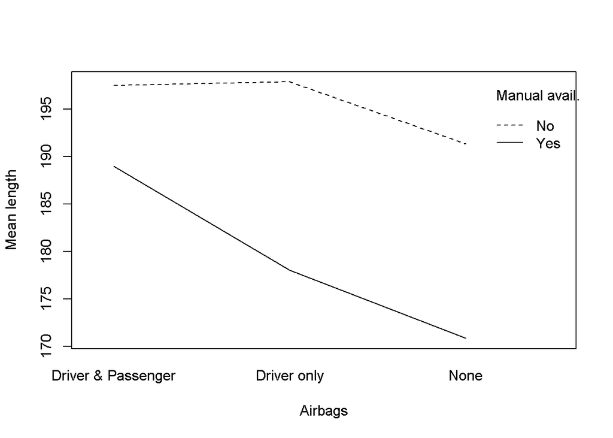

```r
interaction.plot(x.factor=cars.means[,1],
                 trace.factor=cars.means[,2],
                 respons=cars.means$x,
                 trace.label="Manual avail.",
                 xlab="Airbags",
                 ylab="Mean length")
```

```r
# There is some visual indication of interactive behavior owing to the
#non-parallel nature of the two lines; but rememeber there are no
#measures of variability of the various group means displayed on this
#plot...
```

6. Fit a full two-way ANOVA model for the mean lengths according to the two grouping variables (assume satisfaction of all relevant assumptions). Is the interactive effect statistically significant? Is there evidence of any main effects?

```r
summary(aov(Length~AirBags+Man.trans.avail+AirBags:Man.trans.avail,data=Cars93)) # No formal statistical evidence of an interactive effect. Strong evidence of main effects, however -- both 'Airbags' and 'Man.trans.avail' appear to be related to car length.
```

```
##                         Df Sum Sq Mean Sq F value   Pr(>F)
## AirBags                  2   3752    1876  18.048 2.78e-07 ***
## Man.trans.avail          1   6388    6388  61.447 1.05e-11 ***
## AirBags:Man.trans.avail  2    433     217   2.084    0.131
## Residuals               87   9044     104
## ---
## Signif. codes:  0 '***' 0.001 '**' 0.01 '*' 0.05 '.' 0.1 ' ' 1
```

Exercise 20.1 Continue to use the survey data frame from the package MASS for the next few exercises. a. Using your fitted model of student height on writing handspan, survfit, provide point estimates and 99 percent confidence intervals for the mean student height for handspans of 12, 15:2, 17, and 19:9 cm.

```r
library("MASS")
survfit <- lm(Height~Wr.Hnd,data=survey)
#(a)
predict(survfit,newdata=data.frame(Wr.Hnd=c(12,15.2,17,19.9)),interval="confidence",level=0.99)
```

```
##        fit      lwr      upr
## 1 151.3530 146.0901 156.6159
## 2 161.3262 158.3051 164.3473
## 3 166.9361 164.9985 168.8737
## 4 175.9743 174.3066 177.6420
```

2. In Section 20.1, you defined the object incomplete.obs, a numeric vector that provides the records of survey that were automatically removed from consideration when estimating the model parameters. Now, use the incomplete.obs vector along with survey and Equation (20.3) to calculate ˆ 0 and ˆ 1 in R. (Remember the functions mean, sd, and cor. Ensure your answers match the output from survfit.)

```r
incomplete.obs <- which(is.na(survey$Height)|is.na(survey$Wr.Hnd))
rho.xy <- cor(survey$Wr.Hnd,survey$Height,use="complete.obs")
b1 <- sd(survey$Height[-incomplete.obs])/sd(survey$Wr.Hnd[-incomplete.obs])*rho.xy
b1
```

```
## [1] 3.116617
```

```r
b0 <- mean(survey$Height[-incomplete.obs])-b1*mean(survey$Wr.Hnd[-incomplete.obs])
b0
```

```
## [1] 113.9536
```

3. The survey data frame has a number of other variables present aside from Height and Wr.Hnd. For this exercise, the end aim is to fit a simple linear model to predict the mean student height, but this time from their pulse rate, given in Pulse (continue to assume the conditions listed in Section 20.2 are satisfied).
4. Fit the regression model and produce a scatterplot with the fitted line superimposed upon the data. Make sure you can write down the fitted model equation and keep the plot open.

```r
plot(survey$Height~survey$Pulse,xlab="Pulse rate (bpm)",ylab="Height (cm)")
survfit <- lm(Height~Pulse,data=survey)
survfit # Model equation is  y = 177.86 - 0.072x
```

```
##
## Call:
## lm(formula = Height ~ Pulse, data = survey)
##
## Coefficients:
## (Intercept)        Pulse
##   177.85708     -0.07225
```

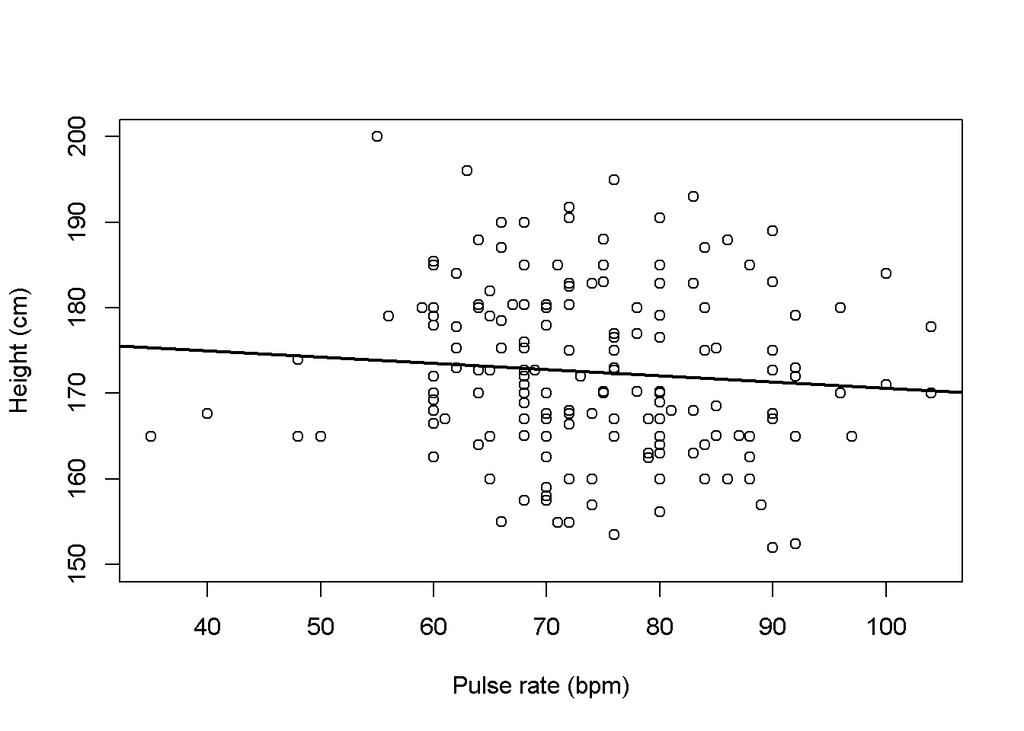

```r
abline(survfit,lwd=2)
```

2. Identify and interpret the point estimate of the slope, as well as the outcome of the test associated with the hypotheses H0 : 1 = 0; HA : 1 , 0. Also find a 90 percent CI for the slope parameter.

```r
summary(survfit) # For each additional bpm, the mean student height is estimated to decrease by 0.072cm; p-value for slope is 0.275. No evidence to reject H0. Insufficient evidence to conclude that pulse rate affects mean student height.
```

```
##
## Call:
## lm(formula = Height ~ Pulse, data = survey)
##
## Residuals:
##      Min       1Q   Median       3Q      Max
## -19.3543  -7.2019  -0.9439   7.2622  26.1168
##
## Coefficients:
##              Estimate Std. Error t value Pr(>|t|)
## (Intercept) 177.85708    4.93485  36.041   <2e-16 ***
## Pulse        -0.07225    0.06598  -1.095    0.275
## ---
## Signif. codes:  0 '***' 0.001 '**' 0.01 '*' 0.05 '.' 0.1 ' ' 1
##
## Residual standard error: 9.884 on 169 degrees of freedom
##   (66 observations deleted due to missingness)
## Multiple R-squared:  0.007046,   Adjusted R-squared:  0.001171
## F-statistic: 1.199 on 1 and 169 DF,  p-value: 0.275
```

```r
confint(survfit,level=0.9)
```

```
##                     5 %         95 %
## (Intercept) 169.6952304 186.01892281
## Pulse        -0.1813757   0.03687061
```

3. Using your model, add lines for 90 percent confidence and prediction interval bands on the plot from (i) and add a legend to differentiate between the lines.

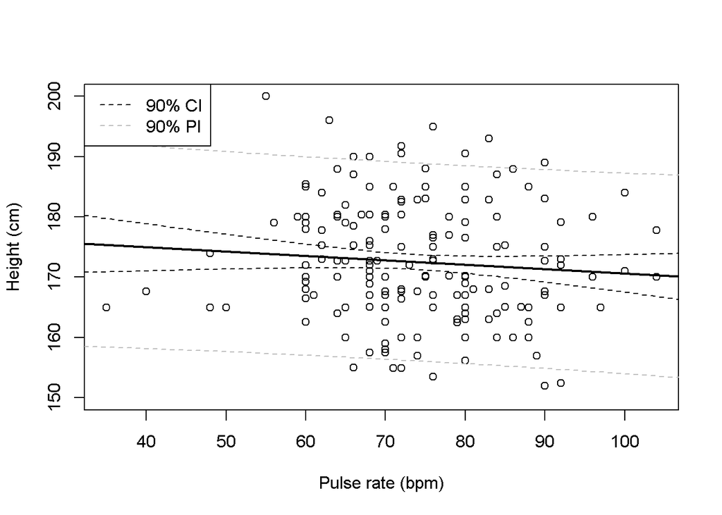

```r
xseq <- data.frame(Pulse=seq(30,110,length=100))
survfit.ci <- predict(survfit,newdata=xseq,interval="confidence",level=0.9)
survfit.pi <- predict(survfit,newdata=xseq,interval="prediction",level=0.9)

plot(survey$Height~survey$Pulse,xlab="Pulse rate (bpm)",ylab="Height (cm)")
abline(survfit,lwd=2)
lines(xseq[,1],survfit.ci[,2],lty=2)
lines(xseq[,1],survfit.ci[,3],lty=2)
lines(xseq[,1],survfit.pi[,2],lty=2,col="grey")
lines(xseq[,1],survfit.pi[,3],lty=2,col="grey")
legend("topleft",legend=c("90% CI","90% PI"),lty=2,col=c("black","grey"))
```

4. Create an incomplete.obs vector for the current “height on pulse” data. Use that vector to calculate the sample mean of the height observations that were used for the model fitted in (i). Then add a perfectly horizontal line to the plot at this mean (use color or line type options to avoid confusion with the other lines present). What do you notice? Does the plot support your conclusions from (ii)?

```r
incomplete.obs <- which(is.na(survey$Height)|is.na(survey$Pulse))
#abline(h=mean(survey$Height[-incomplete.obs]),col=2,lty=3,lwd=3) # The line sits in the middle of the CI bands without breaching them. This supports the conclusion that pulse rate is not significantly related to mean student height.
```

[output not shown]

Next, examine the help file for the mtcars data set, which you first saw in Exercise 13.4 on page 287. For this exercise, the goal is to model fuel efficiency, measured in miles per gallon (MPG), in terms of the overall weight of the vehicle (in thousands of pounds). d. Plot the data—mpg on the y-axis and wt on the x-axis.

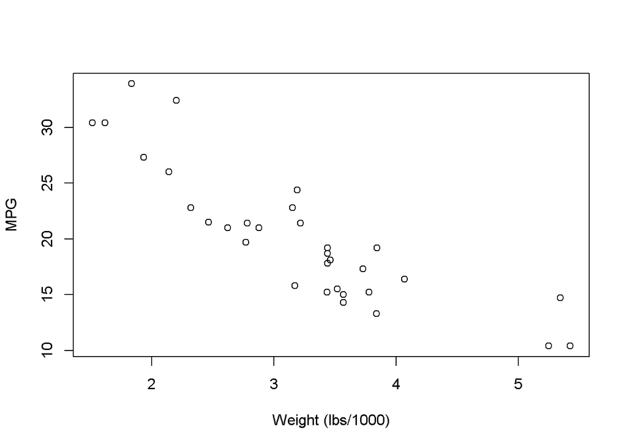

```r
?mtcars
plot(mtcars$mpg~mtcars$wt,xlab="Weight (lbs/1000)",ylab="MPG")
```

5. Fit the simple linear regression model. Add the fitted line to the plot from (d).

```r
carfit <- lm(mpg~wt,data=mtcars)
carfit
```

```
##
## Call:
## lm(formula = mpg ~ wt, data = mtcars)
##
## Coefficients:
## (Intercept)           wt
##      37.285       -5.344
```

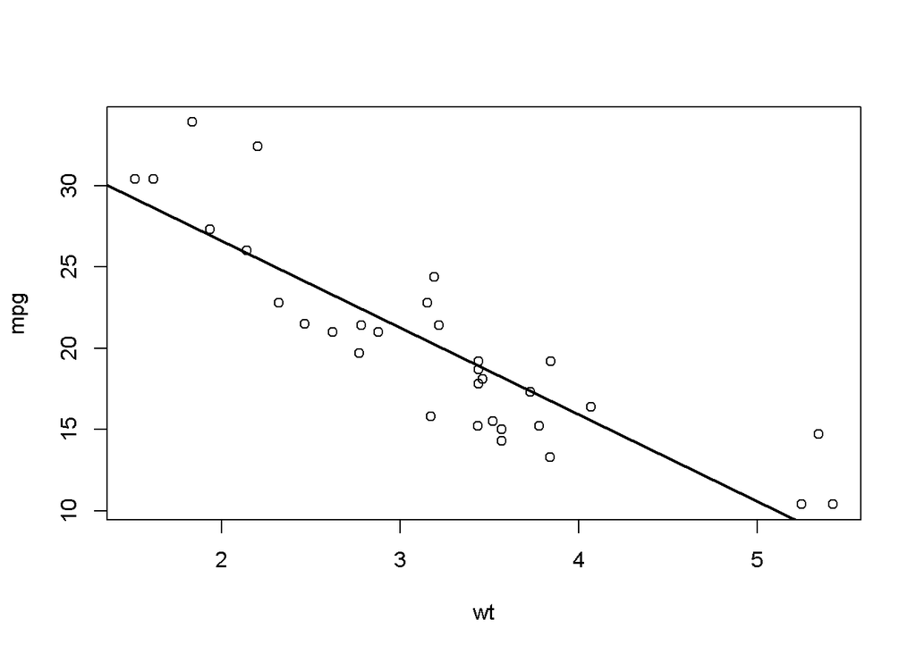

```r
attach(mtcars)
plot(wt,mpg)
abline(carfit,lwd=2)
```

6. Write down the regression equation and interpret the point estimate of the slope. Is the effect of wt on mean mpg estimated to be statistically significant?

```r
summary(carfit) # mean MPG = 37.28 - 5.34*weight # For each extra 1000lbs of weight, the mean MPG decreases by 5.34; p-value for slope is very small---result is statistically significant---strong evidence to suggest that mean MPG changes according to weight (for cars of this era).
```

```
##
## Call:
## lm(formula = mpg ~ wt, data = mtcars)
##
## Residuals:
##     Min      1Q  Median      3Q     Max
## -4.5432 -2.3647 -0.1252  1.4096  6.8727
##
## Coefficients:
##             Estimate Std. Error t value Pr(>|t|)
## (Intercept)  37.2851     1.8776  19.858  < 2e-16 ***
## wt           -5.3445     0.5591  -9.559 1.29e-10 ***
## ---
## Signif. codes:  0 '***' 0.001 '**' 0.01 '*' 0.05 '.' 0.1 ' ' 1
##
## Residual standard error: 3.046 on 30 degrees of freedom
## Multiple R-squared:  0.7528, Adjusted R-squared:  0.7446
## F-statistic: 91.38 on 1 and 30 DF,  p-value: 1.294e-10
```

7. Produce a point estimate and associated 95 percent PI for a car that weighs 6;000 lbs. Do you trust the model to predict observations accurately for this value of the explanatory variable? Why or why not?

```r
predict(carfit,newdata=data.frame(wt=6),interval="prediction",level=0.95) # Predicting at 6000lbs seems untrustworthy. Extrapolation is far enough outside the range of the observed data such that the associated PI has a lower limit that is negative, which makes no sense in terms of the response variable of MPG.
```

```
##        fit      lwr      upr
## 1 5.218297 -1.85279 12.28938
```

Exercise 20.2 Continue using the survey data frame from the package MASS for the next few exercises. a. The survey data set has a variable named Exer, a factor with k = 3 levels describing the amount of physical exercise time each student gets: none, some, or frequent. Obtain a count of the number of students in each category and produce side-by-side boxplots of student height split by exercise.

```r
library("MASS")
#(a)
table(survey$Exer)
```

```
##
## Freq None Some
##  115   24   98
```

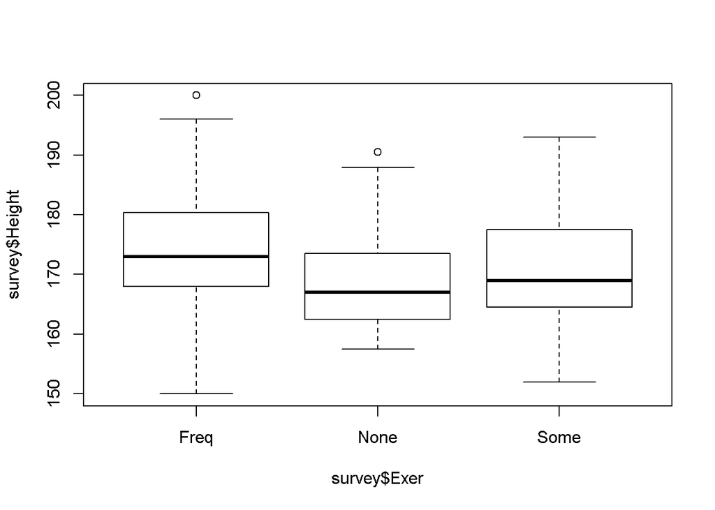

```r
boxplot(survey$Height~survey$Exer)
```

2. Assuming independence of the observations and normality as usual, fit a linear regression model with height as the response variable and exercise as the explanatory variable (dummy coding). What’s the default reference level of the predictor? Produce a model summary.

```r
survfit <- lm(Height~Exer,data=survey)
summary(survfit) # The reference level of the predictor defaults to
```

```
##
## Call:
## lm(formula = Height ~ Exer, data = survey)
##
## Residuals:
##     Min      1Q  Median      3Q     Max
## -24.607  -6.397  -1.607   6.103  25.393
##
## Coefficients:
##             Estimate Std. Error t value Pr(>|t|)
## (Intercept) 174.6067     0.9396 185.836  < 2e-16 ***
## ExerNone     -5.5787     2.3489  -2.375  0.01847 *
## ExerSome     -4.2098     1.4094  -2.987  0.00316 **
## ---
## Signif. codes:  0 '***' 0.001 '**' 0.01 '*' 0.05 '.' 0.1 ' ' 1
##
## Residual standard error: 9.628 on 206 degrees of freedom
##   (28 observations deleted due to missingness)
## Multiple R-squared:  0.05333,    Adjusted R-squared:  0.04414
## F-statistic: 5.802 on 2 and 206 DF,  p-value: 0.003536
```

```r
#the first level of the factor, which in this case (as is the default in R) is
#alphabetically arranged to be 'Freq'.
```

3. Draw a conclusion based on the fitted model from (b)—does it appear that exercise frequency has any impact on mean height? What is the nature of the estimated effect?

** We observe that both of the levels for which we’ve obtained coefficient estimates yield p-values that suggest evidence the coefficients are different to zero. The coefficient corresponding to ‘some’ has the smallest p-value of the two additive dummy levels. The negative point estimates of both estimates tell us that the model predicts the effect on height of being in either the ‘none’ or the ‘some’ categories, when compared to the ‘frequent’ category, is one of a decrease. In other words, it appears those who exercise less than ‘frequent’ are shorter on average. The shortest mean height is reserved for those in the ‘none’ exercise category; the estimated coefficient (-5.58) is more extreme than the coefficient for some’ (-4.21). Overall statistical significance of the predictor (in terms of the effect of exercise on height) is supported by the global (omnibus F-test) P-value of 0.0035.**

4. Predict the mean heights of one individual in each of the three exercise categories, accompanied by 95 percent prediction intervals.

```r
one.of.each <- factor(levels(survey$Exer))
one.of.each
```

```
## [1] Freq None Some
## Levels: Freq None Some
```

```r
predict(survfit,newdata=data.frame(Exer=one.of.each),interval="prediction")
```

```
##        fit      lwr      upr
## 1 174.6067 155.5349 193.6784
## 2 169.0280 149.5777 188.4783
## 3 170.3969 151.3027 189.4911
```

5. Do you arrive at the same result and interpretation for the height-by-exercise model if you construct an ANOVA table using aov?

```r
summary(aov(Height~Exer,data=survey)) # Same 'global' P-value as the lm model
```

```
##              Df Sum Sq Mean Sq F value  Pr(>F)
## Exer          2   1076   537.8   5.802 0.00354 **
## Residuals   206  19095    92.7
## ---
## Signif. codes:  0 '***' 0.001 '**' 0.01 '*' 0.05 '.' 0.1 ' ' 1
## 28 observations deleted due to missingness
```

```r
#summary. There is evidence to suggest mean student height differs according to
#exercise frequency.
```

6. Is there any change to the outcome of (e) if you alter the model so that the reference level of the exercise variable is “none”? Would you expect there to be? Now, turn back to the ready-to-use mtcars data set. One of the variables in this data frame is qsec, described as the time in seconds it takes to race a quarter mile; another is gear, the number of forward gears (cars in this data set have either 3, 4, or 5 gears).

```r
ExerReordered <- relevel(survey$Exer,ref="None")
levels(ExerReordered)
```

```
## [1] "None" "Freq" "Some"
```

```r
summary(aov(Height~ExerReordered,data=survey))
```

```
##                Df Sum Sq Mean Sq F value  Pr(>F)
## ExerReordered   2   1076   537.8   5.802 0.00354 **
## Residuals     206  19095    92.7
## ---
## Signif. codes:  0 '***' 0.001 '**' 0.01 '*' 0.05 '.' 0.1 ' ' 1
## 28 observations deleted due to missingness
```

```r
# There is no change to the omnibus F-test if we reorder the the reference level
#of exercise to be 'none', and nor should we expect there to be. The global test
#of a difference between the means doesn't depend on what we set the baseline
#value of the response to be.
```

7. Using the vectors straight from the data frame, fit a simple linear regression model with qsec as the response variable and gear as the explanatory variable and interpret the model summary.

```r
carfit <- lm(qsec~gear,data=mtcars)
summary(carfit) # The effect of 'gear' when treated as a continuous variable is
```

```
##
## Call:
## lm(formula = qsec ~ gear, data = mtcars)
##
## Residuals:
##     Min      1Q  Median      3Q     Max
## -2.7929 -1.1604 -0.3278  1.2122  5.2122
##
## Coefficients:
##             Estimate Std. Error t value Pr(>|t|)
## (Intercept)  19.7482     1.6239  12.161    4e-13 ***
## gear         -0.5151     0.4321  -1.192    0.243
## ---
## Signif. codes:  0 '***' 0.001 '**' 0.01 '*' 0.05 '.' 0.1 ' ' 1
##
## Residual standard error: 1.775 on 30 degrees of freedom
## Multiple R-squared:  0.04523,    Adjusted R-squared:  0.01341
## F-statistic: 1.421 on 1 and 30 DF,  p-value: 0.2425
```

```r
#interpreted as a decrease in quarter-mile time of around 0.5 seconds, on
#average, for each additional forward gear. However, there is no evidence that
#this effect is different to zero, with a high P-value of 0.243 (and a similar
#global p-value)
```

8. Explicitly convert gear to a factor vector and refit the model. Compare the model summary with that from (g). What do you find?

```r
#(h)
carfit2 <- lm(qsec~factor(gear),data=mtcars)
summary(carfit2) # The effect of 'gear' when treated as a categorical variable
```

```
##
## Call:
## lm(formula = qsec ~ factor(gear), data = mtcars)
##
## Residuals:
##     Min      1Q  Median      3Q     Max
## -2.5050 -0.6667 -0.2060  0.6125  3.9350
##
## Coefficients:
##               Estimate Std. Error t value Pr(>|t|)
## (Intercept)    17.6920     0.3691  47.928  < 2e-16 ***
## factor(gear)4   1.2730     0.5537   2.299  0.02890 *
## factor(gear)5  -2.0520     0.7383  -2.779  0.00946 **
## ---
## Signif. codes:  0 '***' 0.001 '**' 0.01 '*' 0.05 '.' 0.1 ' ' 1
##
## Residual standard error: 1.43 on 29 degrees of freedom
## Multiple R-squared:  0.4012, Adjusted R-squared:  0.3599
## F-statistic: 9.715 on 2 and 29 DF,  p-value: 0.0005897
```

```r
#now appears to be statistically significant. Having 4 gears (as opposed to the
#reference level of 3) seems to increase the mean quarter-mile time by 1.27
#seconds, having 5 gears appears to decrease the mean quarter-mile time by 2.05
#seconds. The global (omnibus F-test) p-value is also quite small, yielding
#evidence in support of an effect of 'gear' on 'qsec'.
```

1. Explain, with the aid of a relevant plot in the same style as the right image of Figure 20-6, why you think there is a difference between the two models (g) and (h).

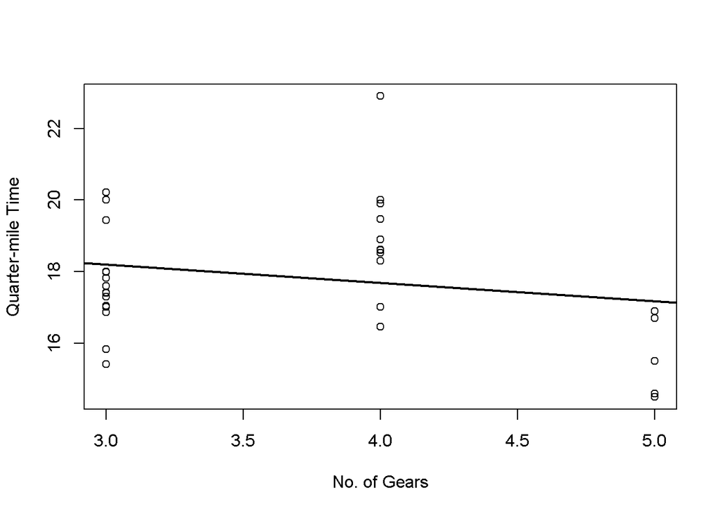

```r
plot(mtcars$qsec~mtcars$gear,xlab="No. of Gears",ylab="Quarter-mile Time")
abline(carfit,lwd=2) # The plot indicates clearly that the difference between
```

```r
#the two models is due to the fact that the relationship cannot be well
#explained by a continuous straight line. The first model therefore is incapable
#of realistically capturing the effect of changing categories in 'gear' on
#'qsec'.
```

# chapter 21 :MULTIPLE LINEAR REGRESSION